# The Jeffreys prior for skew–symmetric models

[F. Javier Rubio](https://sites.google.com/site/fjavierrubio67/)

16 July, 2017

## The Jeffreys prior for the skewness parameter in skew–symmetric models

Skew–symmetric models were defined in [1] in terms of the probability density function:

$$s(y;\mu,\sigma,\lambda) = \dfrac{2}{\sigma} f\left(\dfrac{y-\mu}{\sigma}\right)G \left(\lambda \dfrac{y-\mu}{\sigma}\right),$$
where $f$ is a continuous symmetric density function with support on ${\mathbb R}$, and $G$ is a CDF with continuous symmetric density $g$ with support on ${\mathbb R}$. [2] found that under mild regularity conditions the Jeffreys prior of $\lambda$ is given by:

$$\pi(\lambda) \propto \sqrt{ \int_0^{\infty} x^2 f(x)\dfrac{g(\lambda x)^2}{G(\lambda x)[1-G(\lambda x)]} dx}.$$

This prior satisfies [2]

1. $\pi(\lambda)$ is symmetric about $0$.
2. The tails of $\pi(\lambda)$ are of order $O(\vert\lambda\vert^{-\frac{3}{2}})$.
3. $\pi(\lambda)$ is integrable.

Using these properties, [2] proposed a tractable approximation to the Jeffreys prior of $\lambda$ using a $t$ distribution with $1/2$ degrees of freedom (to match the tails) and different scale parameters depending on the model: $\pi/2$ for the skew-normal, and $4/3$ for the skew-logistic.

The following R code shows the implementation of this prior for the skew-normal and skew-logistic models as well as their $t$-approximations.

**References**

1. [A Class of Distributions Which Includes the Normal Ones](http://www.jstor.org/stable/4615982)
2. [On the independence Jeffreys prior for skew-symmetric models](https://doi.org/10.1016/j.spl.2013.11.012)

```r
rm(list=ls())

#-----------------------------------------------------------------------
#-----------------------------------------------------------------------
# Jeffreys prior for the skew-normal and t-approximation
#-----------------------------------------------------------------------
#-----------------------------------------------------------------------

# Integration region over x and lambda
# The integration range requires some tweaks to make it numerically stable
Ux <- 6
Ul <- 449

# Un-normalised Jeffreys prior
tempf <- Vectorize(function(lambda){
  fun <- Vectorize(function(x){
    exp( 2*log(x) + dnorm(x,log=T) + 2*dnorm(lambda*x,log=T) -pnorm(lambda*x,log=T) - pnorm(-lambda*x,log=T) )
  })
  if(lambda>400) temp.var <- integrate(fun,0,0.015,rel.tol=1e-9, subdivisions = 1000)$val
  if(lambda>100) temp.var <- integrate(fun,0,0.05,rel.tol=1e-9, subdivisions = 1000)$val
  if(lambda>10) temp.var <- integrate(fun,0,0.5,rel.tol=1e-9, subdivisions = 1000)$val
  if(lambda>5) temp.var <- integrate(fun,0,1,rel.tol=1e-9, subdivisions = 1000)$val
  if(lambda<=5) temp.var <- integrate(fun,0,Ux,rel.tol=1e-9, subdivisions = 1000)$val
  return(sqrt(temp.var))
})

# Normalising constant
int.con <- 2*integrate(tempf,0,Ul,rel.tol=1e-9, subdivisions = 1000)$value
int.con
```

```
## [1] 3.188822
```

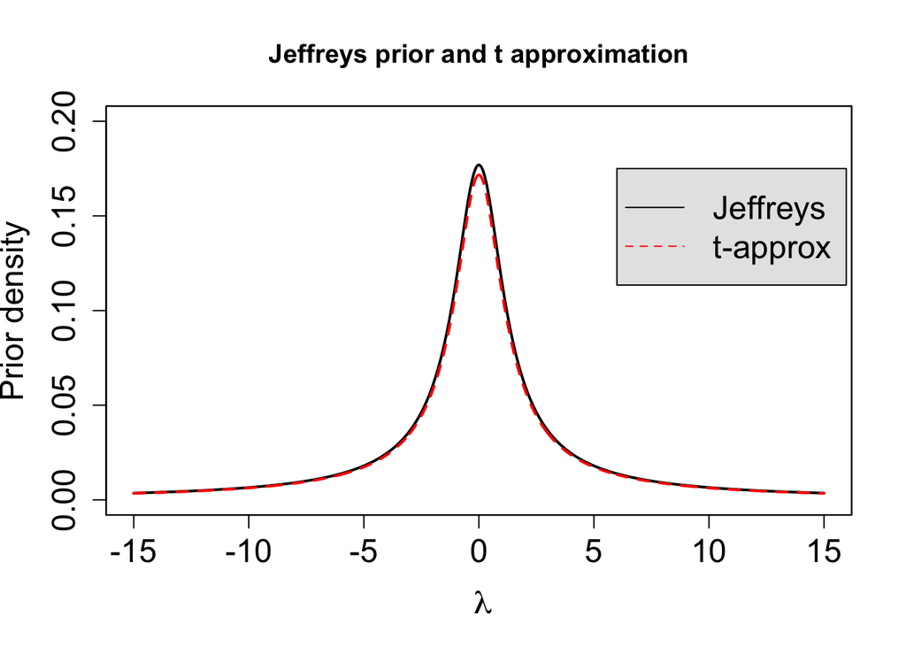

```r
# Normalised Jeffreys prior
piJ <- Vectorize(function(lambda){
  return(tempf(lambda)/int.con)
})

# t-approximation
c <-pi/2 # scale parameter
t.approx <- function(x) dt(x/c,df=1/2)/c

# Comparison
curve(piJ,-15,15,n=1000,xlab=~lambda,ylab="Prior density",main="Jeffreys prior and t approximation",cex.lab=1.5,cex.axis=1.5,lwd=2,ylim=c(0,0.2))
curve(t.approx,-15,15,add=T,lty=2,col="red",lwd=2,n=1000)
box()
legend(6, 0.175, c("Jeffreys","t-approx"), col=c("black","red"),
       text.col = "black", lty = c(1, 2),
       merge = TRUE, bg = "gray90",cex=1.5)
```

```r
rm(list=ls())

#-----------------------------------------------------------------------
#-----------------------------------------------------------------------
# Jeffreys prior for the skew-logistic and t-approximation
#-----------------------------------------------------------------------
#-----------------------------------------------------------------------

# Integration region over x and lambda
# The integration range requires some tweaks to make it numerically stable
Ux <- 6
Ul <- 449

# Un-normalised Jeffreys prior
tempf <- Vectorize(function(lambda){
  fun <- Vectorize(function(x){
    exp( 2*log(x) + dlogis(x,log=T) + 2*dlogis(lambda*x,log=T) -plogis(lambda*x,log=T) - plogis(-lambda*x,log=T) )
  })
  if(lambda>400) temp.var <- integrate(fun,0,0.015,rel.tol=1e-9, subdivisions = 1000)$val
  if(lambda>100) temp.var <- integrate(fun,0,0.05,rel.tol=1e-9, subdivisions = 1000)$val
  if(lambda>10) temp.var <- integrate(fun,0,0.5,rel.tol=1e-9, subdivisions = 1000)$val
  if(lambda>5) temp.var <- integrate(fun,0,1,rel.tol=1e-9, subdivisions = 1000)$val
  if(lambda<=5) temp.var <- integrate(fun,0,Ux,rel.tol=1e-9, subdivisions = 1000)$val
  return(sqrt(temp.var))
})

# Normalising constant
int.con <- 2*integrate(tempf,0,Ul,rel.tol=1e-9, subdivisions = 1000)$value
int.con
```

```
## [1] 3.016586
```

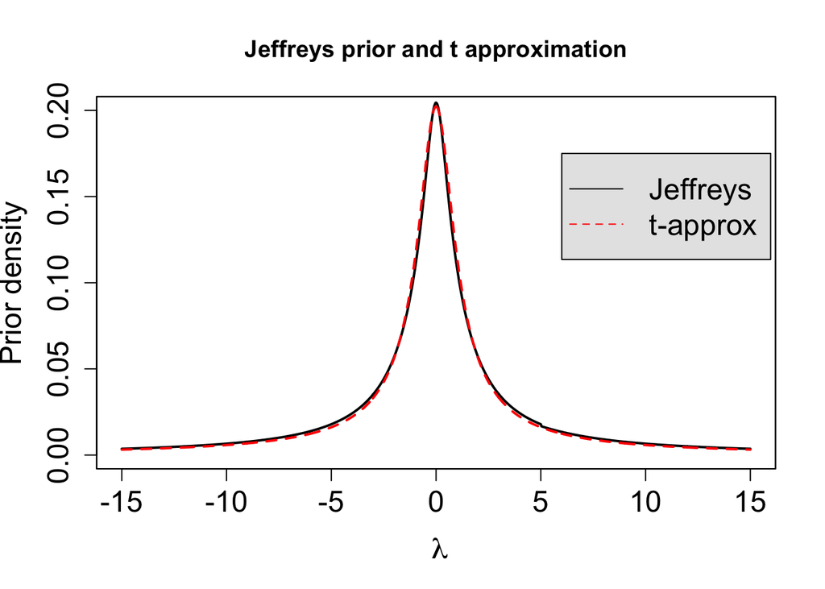

```r
# Normalised Jeffreys prior
piJ <- Vectorize(function(lambda){
  return(tempf(lambda)/int.con)
})

# t-approximation
c <-4/3 # scale parameter
t.approx <- function(x) dt(x/c,df=1/2)/c

# Comparison
curve(piJ,-15,15,n=1000,xlab=~lambda,ylab="Prior density",main="Jeffreys prior and t approximation",cex.lab=1.5,cex.axis=1.5,lwd=2,ylim=c(0,0.2))
curve(t.approx,-15,15,add=T,lty=2,col="red",lwd=2,n=1000)
box()
legend(6, 0.175, c("Jeffreys","t-approx"), col=c("black","red"),
       text.col = "black", lty = c(1, 2),
       merge = TRUE, bg = "gray90",cex=1.5)
```